# Project: Police killings

Data: https://github.com/fivethirtyeight/data/tree/master/police-killings

```python
import pandas as pandas
police_killings = pandas.read_csv('police_killings.csv', encoding='iso8859_1')
```

```python
police_killings.head()
```

|  | name | age | gender | raceethnicity | month | day | year | streetaddress | city | state | ... | share_hispanic | p_income | h_income | county_income | comp_income | county_bucket | nat_bucket | pov | urate | college |
| --- | --- | --- | --- | --- | --- | --- | --- | --- | --- | --- | --- | --- | --- | --- | --- | --- | --- | --- | --- | --- | --- |
| 0 | A'donte Washington | 16 | Male | Black | February | 23 | 2015 | Clearview Ln | Millbrook | AL | ... | 5.6 | 28375 | 51367 | 54766 | 0.937936 | 3 | 3 | 14.1 | 0.097686 | 0.168510 |
| 1 | Aaron Rutledge | 27 | Male | White | April | 2 | 2015 | 300 block Iris Park Dr | Pineville | LA | ... | 0.5 | 14678 | 27972 | 40930 | 0.683411 | 2 | 1 | 28.8 | 0.065724 | 0.111402 |
| 2 | Aaron Siler | 26 | Male | White | March | 14 | 2015 | 22nd Ave and 56th St | Kenosha | WI | ... | 16.8 | 25286 | 45365 | 54930 | 0.825869 | 2 | 3 | 14.6 | 0.166293 | 0.147312 |
| 3 | Aaron Valdez | 25 | Male | Hispanic/Latino | March | 11 | 2015 | 3000 Seminole Ave | South Gate | CA | ... | 98.8 | 17194 | 48295 | 55909 | 0.863814 | 3 | 3 | 11.7 | 0.124827 | 0.050133 |
| 4 | Adam Jovicic | 29 | Male | White | March | 19 | 2015 | 364 Hiwood Ave | Munroe Falls | OH | ... | 1.7 | 33954 | 68785 | 49669 | 1.384868 | 5 | 4 | 1.9 | 0.063550 | 0.403954 |

5 rows × 34 columns

```python
police_killings.columns
```

```
Index(['name', 'age', 'gender', 'raceethnicity', 'month', 'day', 'year', 'streetaddress', 'city', 'state', 'latitude', 'longitude', 'state_fp', 'county_fp', 'tract_ce', 'geo_id', 'county_id', 'namelsad', 'lawenforcementagency', 'cause', 'armed', 'pop', 'share_white', 'share_black', 'share_hispanic',…
```

```python
counts = police_killings['raceethnicity'].value_counts()
```

```python
print(counts)
```

```
White                     236
Black                     135
Hispanic/Latino            67
Unknown                    15
Asian/Pacific Islander     10
Native American             4
dtype: int64
```

```
 <a list of 6 Text xticklabel objects>)
```

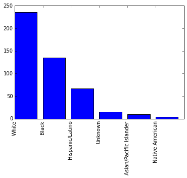

```python
import matplotlib.pyplot as plt
%matplotlib inline
import numpy as np

plt.bar(range(6), counts)
plt.xticks(range(6), counts.index, rotation="vertical")
```

```python
counts / sum(counts)
```

```
White                     0.505353
Black                     0.289079
Hispanic/Latino           0.143469
Unknown                   0.032120
Asian/Pacific Islander    0.021413
Native American           0.008565
dtype: float64
```

## Racial breakdown

It looks like people identified as Black are far overrepresented in the shootings versus in the population of the US (28% vs 16%). You can see the breakdown of population by race here: https://en.wikipedia.org/wiki/Race_and_ethnicity_in_the_United_States#Racial_makeup_of_the_U.S._population

People identified as Hispanic appear to be killed about as often as random chance would account for (14% of the people killed as Hispanic, versus 17% of the overall population). Whites are underrepresented among shooting victims vs their population percentage, as are Asians.

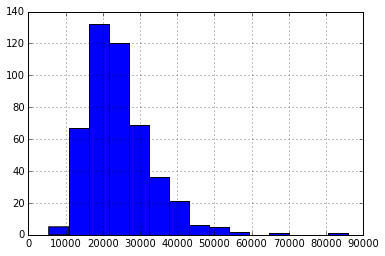

```python
police_killings["p_income"][police_killings["p_income"] != "-"].astype(float).hist(bins=15)
```

# Income breakdown

According to the Census, median personal income in the US is 28,567, and our median is 22,348, which means that shootings tend to happen in less affluent areas. Our sample size is relatively small, though, so it's hard to make sweeping conclusions.

```python
state_pop = pandas.read_csv('state_population.csv')
```

```python
counts = police_killings["state_fp"].value_counts()
```

```python
states = pandas.DataFrame({"STATE": counts.index, "shootings": counts })
```

```python
states = states.merge(state_pop, on="STATE")
```

```python
states["pop_millions"] = states["POPESTIMATE2015"] / 1000000
states["rate"] = states["shootings"] / states["pop_millions"]

states.sort("rate")
```

|  | STATE | shootings | SUMLEV | REGION | DIVISION | NAME | POPESTIMATE2015 | POPEST18PLUS2015 | PCNT_POPEST18PLUS | pop_millions | rate |
| --- | --- | --- | --- | --- | --- | --- | --- | --- | --- | --- | --- |
| 43 | 9 | 1 | 40 | 1 | 1 | Connecticut | 3590886 | 2826827 | 78.7 | 3.590886 | 0.278483 |
| 22 | 42 | 7 | 40 | 1 | 2 | Pennsylvania | 12802503 | 10112229 | 79.0 | 12.802503 | 0.546768 |
| 38 | 19 | 2 | 40 | 2 | 4 | Iowa | 3123899 | 2395103 | 76.7 | 3.123899 | 0.640226 |
| 6 | 36 | 13 | 40 | 1 | 2 | New York | 19795791 | 15584974 | 78.7 | 19.795791 | 0.656705 |
| 29 | 25 | 5 | 40 | 1 | 1 | Massachusetts | 6794422 | 5407335 | 79.6 | 6.794422 | 0.735898 |
| 42 | 33 | 1 | 40 | 1 | 1 | New Hampshire | 1330608 | 1066610 | 80.2 | 1.330608 | 0.751536 |
| 45 | 23 | 1 | 40 | 1 | 1 | Maine | 1329328 | 1072948 | 80.7 | 1.329328 | 0.752260 |
| 11 | 17 | 11 | 40 | 2 | 3 | Illinois | 12859995 | 9901322 | 77.0 | 12.859995 | 0.855366 |
| 12 | 39 | 10 | 40 | 2 | 3 | Ohio | 11613423 | 8984946 | 77.4 | 11.613423 | 0.861073 |
| 31 | 55 | 5 | 40 | 2 | 3 | Wisconsin | 5771337 | 4476711 | 77.6 | 5.771337 | 0.866350 |
| 16 | 26 | 9 | 40 | 2 | 3 | Michigan | 9922576 | 7715272 | 77.8 | 9.922576 | 0.907023 |
| 28 | 47 | 6 | 40 | 3 | 6 | Tennessee | 6600299 | 5102688 | 77.3 | 6.600299 | 0.909050 |
| 15 | 37 | 10 | 40 | 3 | 5 | North Carolina | 10042802 | 7752234 | 77.2 | 10.042802 | 0.995738 |
| 36 | 32 | 3 | 40 | 4 | 8 | Nevada | 2890845 | 2221681 | 76.9 | 2.890845 | 1.037759 |
| 18 | 51 | 9 | 40 | 3 | 5 | Virginia | 8382993 | 6512571 | 77.7 | 8.382993 | 1.073602 |
| 40 | 54 | 2 | 40 | 3 | 5 | West Virginia | 1844128 | 1464532 | 79.4 | 1.844128 | 1.084523 |
| 25 | 27 | 6 | 40 | 2 | 4 | Minnesota | 5489594 | 4205207 | 76.6 | 5.489594 | 1.092977 |
| 20 | 18 | 8 | 40 | 2 | 3 | Indiana | 6619680 | 5040224 | 76.1 | 6.619680 | 1.208518 |
| 8 | 34 | 11 | 40 | 1 | 2 | New Jersey | 8958013 | 6959192 | 77.7 | 8.958013 | 1.227951 |
| 35 | 5 | 4 | 40 | 3 | 7 | Arkansas | 2978204 | 2272904 | 76.3 | 2.978204 | 1.343091 |
| 2 | 12 | 29 | 40 | 3 | 5 | Florida | 20271272 | 16166143 | 79.7 | 20.271272 | 1.430596 |
| 44 | 11 | 1 | 40 | 3 | 5 | District of Columbia | 672228 | 554121 | 82.4 | 0.672228 | 1.487591 |
| 9 | 53 | 11 | 40 | 4 | 9 | Washington | 7170351 | 5558509 | 77.5 | 7.170351 | 1.534095 |
| 5 | 13 | 16 | 40 | 3 | 5 | Georgia | 10214860 | 7710688 | 75.5 | 10.214860 | 1.566346 |
| 23 | 21 | 7 | 40 | 3 | 6 | Kentucky | 4425092 | 3413425 | 77.1 | 4.425092 | 1.581888 |
| 13 | 29 | 10 | 40 | 2 | 4 | Missouri | 6083672 | 4692196 | 77.1 | 6.083672 | 1.643744 |
| 21 | 1 | 8 | 40 | 3 | 6 | Alabama | 4858979 | 3755483 | 77.3 | 4.858979 | 1.646436 |
| 14 | 24 | 10 | 40 | 3 | 5 | Maryland | 6006401 | 4658175 | 77.6 | 6.006401 | 1.664891 |
| 30 | 49 | 5 | 40 | 4 | 8 | Utah | 2995919 | 2083423 | 69.5 | 2.995919 | 1.668937 |
| 46 | 56 | 1 | 40 | 4 | 8 | Wyoming | 586107 | 447212 | 76.3 | 0.586107 | 1.706173 |
| 1 | 48 | 47 | 40 | 3 | 7 | Texas | 27469114 | 20257343 | 73.7 | 27.469114 | 1.711013 |
| 17 | 45 | 9 | 40 | 3 | 5 | South Carolina | 4896146 | 3804558 | 77.7 | 4.896146 | 1.838180 |
| 0 | 6 | 74 | 40 | 4 | 9 | California | 39144818 | 30023902 | 76.7 | 39.144818 | 1.890416 |
| 37 | 30 | 2 | 40 | 4 | 8 | Montana | 1032949 | 806529 | 78.1 | 1.032949 | 1.936204 |
| 19 | 41 | 8 | 40 | 4 | 9 | Oregon | 4028977 | 3166121 | 78.6 | 4.028977 | 1.985616 |
| 26 | 28 | 6 | 40 | 3 | 6 | Mississippi | 2992333 | 2265485 | 75.7 | 2.992333 | 2.005124 |
| 24 | 20 | 6 | 40 | 2 | 4 | Kansas | 2911641 | 2192084 | 75.3 | 2.911641 | 2.060694 |
| 41 | 10 | 2 | 40 | 3 | 5 | Delaware | 945934 | 741548 | 78.4 | 0.945934 | 2.114312 |
| 7 | 8 | 12 | 40 | 4 | 8 | Colorado | 5456574 | 4199509 | 77.0 | 5.456574 | 2.199182 |
| 10 | 22 | 11 | 40 | 3 | 7 | Louisiana | 4670724 | 3555911 | 76.1 | 4.670724 | 2.355095 |
| 32 | 35 | 5 | 40 | 4 | 8 | New Mexico | 2085109 | 1588201 | 76.2 | 2.085109 | 2.397956 |
| 33 | 16 | 4 | 40 | 4 | 8 | Idaho | 1654930 | 1222093 | 73.8 | 1.654930 | 2.417021 |
| 39 | 2 | 2 | 40 | 4 | 9 | Alaska | 738432 | 552166 | 74.8 | 0.738432 | 2.708442 |
| 34 | 15 | 4 | 40 | 4 | 9 | Hawaii | 1431603 | 1120770 | 78.3 | 1.431603 | 2.794071 |
| 27 | 31 | 6 | 40 | 2 | 4 | Nebraska | 1896190 | 1425853 | 75.2 | 1.896190 | 3.164240 |
| 3 | 4 | 25 | 40 | 4 | 8 | Arizona | 6828065 | 5205215 | 76.2 | 6.828065 | 3.661359 |
| 4 | 40 | 22 | 40 | 3 | 7 | Oklahoma | 3911338 | 2950017 | 75.4 | 3.911338 | 5.624674 |

## Killings by state

```python
police_killings["state"].value_counts()
```

[output not shown]

```python
pk = police_killings[
    (police_killings["share_white"] != "-") &
    (police_killings["share_black"] != "-") &
    (police_killings["share_hispanic"] != "-")
]

pk["share_white"] = pk["share_white"].astype(float)
pk["share_black"] = pk["share_black"].astype(float)
pk["share_hispanic"] = pk["share_hispanic"].astype(float)
```

```python
lowest_states = ["CT", "PA", "IA", "NY", "MA", "NH", "ME", "IL", "OH", "WI"]
highest_states = ["OK", "AZ", "NE", "HI", "AK", "ID", "NM", "LA", "CO", "DE"]

ls = pk[pk["state"].isin(lowest_states)]
hs = pk[pk["state"].isin(highest_states)]
```

```python
columns = ["pop", "county_income", "share_white", "share_black", "share_hispanic"]

ls[columns].mean()
```

```
pop                4201.660714
county_income     54830.839286
share_white          60.616071
share_black          21.257143
share_hispanic       12.948214
dtype: float64
```

```python
hs[columns].mean()
```

```
pop                4315.750000
county_income     48706.967391
share_white          55.652174
share_black          11.532609
share_hispanic       20.693478
dtype: float64
```

## State by state rates

It looks like the states with low rates of shootings tend to have a higher proportion of blacks in the population, and a lower proportion of hispanics in the census regions where the shootings occur. It looks like the income of the counties where the shootings occur is higher. States with high rates of shootings tend to have high hispanic population shares in the counties where shootings occur.